# Data Visualization Final Project: Diamond Attributes and Pricing

Sipra Mishra

2026-10-31

## Introduction

This report explores the diamonds dataset from the ggplot2 package. It contains data on 53,940 diamonds, detailing their physical dimensions, quality metrics (the 4 Cs: Carat, Cut, Color, Clarity), and price. The analysis below satisfies the requirement of presenting eight polished, distinct graphics across multiple figure types to deliver rich data insights.

## Figure Type 1: Distribution Analyses

## Figure 1: Distribution of Diamond Prices

This histogram visualizes the distribution of diamond prices across the entire dataset, utilizing a log-transformed scale to account for severe right-skewness.

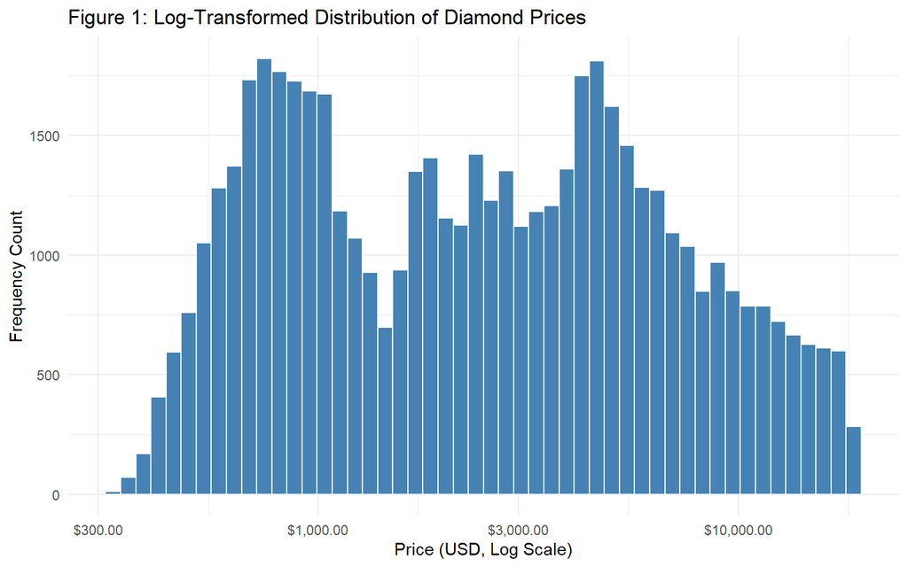

```r
ggplot(diamonds, aes(x = price)) +
  geom_histogram(bins = 50, fill = "steelblue", color = "white") +
  scale_x_log10(labels = scales::dollar_format()) +
  labs(title = "Figure 1: Log-Transformed Distribution of Diamond Prices",
       x = "Price (USD, Log Scale)",
       y = "Frequency Count") +
  theme_minimal()
```

## Figure 2: Carat Weight Distribution

Understanding how carat weight is distributed helps contextualize pricing clusters.

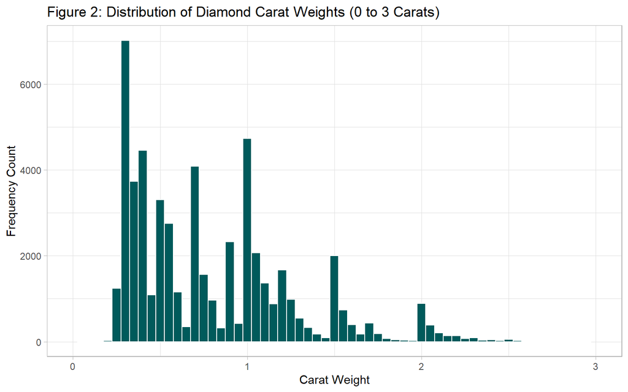

```r
ggplot(diamonds, aes(x = carat)) +
  geom_histogram(binwidth = 0.05, fill = "#005A5B", color = "white") +
  xlim(0, 3) +
  labs(title = "Figure 2: Distribution of Diamond Carat Weights (0 to 3 Carats)",
       x = "Carat Weight",
       y = "Frequency Count") +
  theme_light()
```

## Figure 3: Price Variance Across Diamond Cuts

This box plot displays the distribution of prices across different quality cuts, highlighting the median and outlier ranges.

[figure not shown]

```r
ggplot(diamonds, aes(x = cut, y = price, fill = cut)) +
  geom_boxplot(outlier.alpha = 0.1) +
  scale_y_log10(labels = scales::dollar_format()) +
  scale_fill_brewer(palette = "Purple-Blue") +
  labs(title = "Figure 3: Diamond Price Distribution Across Cut Qualities",
       x = "Quality of the Cut",
       y = "Price (USD, Log Scale)",
       fill = "Cut Grade") +
  theme_minimal()
```

## Figure Type 2: Relationships & Trends

## Figure 4: Carat Weight vs. Price

This scatter plot maps out the primary driver of diamond valuation: the relationship between carat size and market price.

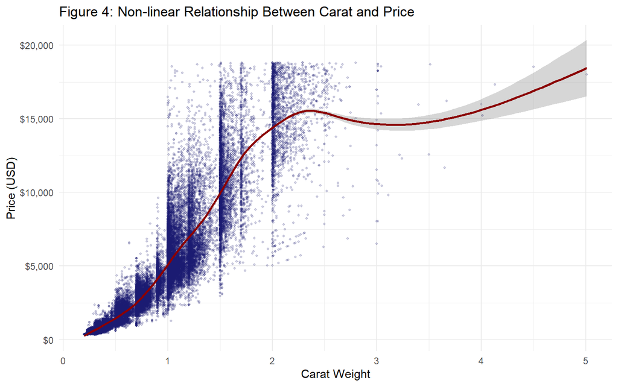

```r
ggplot(diamonds, aes(x = carat, y = price)) +
  geom_point(alpha = 0.2, color = "midnightblue", size = 0.8) +
  geom_smooth(method = "gam", color = "darkred", size = 1) +
  scale_y_continuous(labels = scales::dollar_format()) +
  labs(title = "Figure 4: Non-linear Relationship Between Carat and Price",
       x = "Carat Weight",
       y = "Price (USD)") +
  theme_minimal()
```

## Figure 5: Depth vs. Table Percentage by Cut Quality

A deeper look into how the geometric proportions (depth % vs. table %) relate to one another based on cut categories.

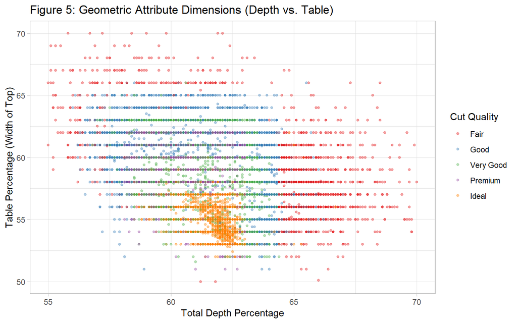

```r
ggplot(diamonds, aes(x = depth, y = table, color = cut)) +
  geom_point(alpha = 0.4, size = 1) +
  xlim(55, 70) +
  ylim(50, 70) +
  scale_color_brewer(palette = "Set1") +
  labs(title = "Figure 5: Geometric Attribute Dimensions (Depth vs. Table)",
       x = "Total Depth Percentage",
       y = "Table Percentage (Width of Top)",
       color = "Cut Quality") +
  theme_light()
```

## Figure Type 3: Comparisons

## Figure 6: Average Price by Color Grade

Using a calculated summary dataset, this bar chart compares the mean market price across different diamond color grades (D is colorless, J is noticeable color).

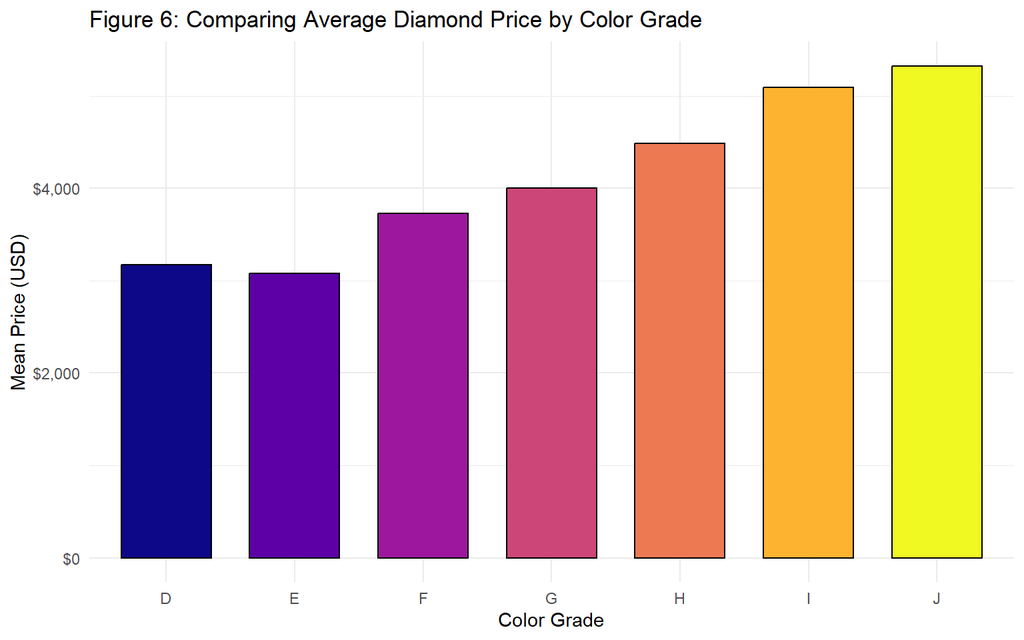

```r
color_summary <- diamonds %>%
  group_by(color) %>%
  summarise(mean_price = mean(price))

ggplot(color_summary, aes(x = color, y = mean_price, fill = color)) +
  geom_bar(stat = "identity", color = "black", width = 0.7) +
  scale_fill_viridis_d(option = "plasma") +
  scale_y_continuous(labels = scales::dollar_format()) +
  labs(title = "Figure 6: Comparing Average Diamond Price by Color Grade",
       x = "Color Grade",
       y = "Mean Price (USD)") +
  theme_minimal() +
  theme(legend.position = "none")
```

## Figure 7: Diamond Count Profiles by Clarity Range

This visualization contrasts the absolute inventory availability of diamonds segmented by clarity scales.

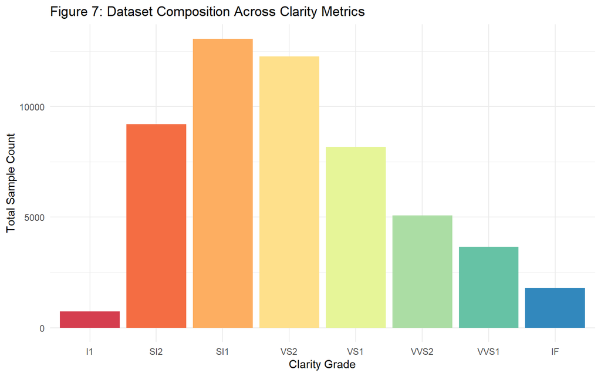

```r
ggplot(diamonds, aes(x = clarity, fill = clarity)) +
  geom_bar() +
  scale_fill_brewer(palette = "Spectral") +
  labs(title = "Figure 7: Dataset Composition Across Clarity Metrics",
       x = "Clarity Grade",
       y = "Total Sample Count") +
  theme_minimal() +
  theme(legend.position = "none")
```

## Interactive Visualization

## Figure 8: Interactive Analysis of Carat, Price, and Clarity

To meet the core interactive submission criteria, this scatter plot utilizes a smaller random sample subset of 1,000 diamonds for fluid interface performance, rendered directly via plotly. Hover over data points to review precise individual metrics.

```r
set.seed(42)
sampled_diamonds <- diamonds %>% sample_n(1000)

p <- ggplot(sampled_diamonds, aes(x = carat, y = price, color = clarity, text = paste("Cut:", cut))) +
  geom_point(alpha = 0.7) +
  scale_y_continuous(labels = scales::dollar_format()) +
  labs(title = "Figure 8: Interactive Scatter Map of Size vs. Valuation",
       x = "Carat Weight",
       y = "Price (USD)",
       color = "Clarity") +
  theme_minimal()
```

```r
ggplotly(p, tooltip = c("x", "y", "color", "text"))
```

[interactive chart not shown]